# Data Science Examples and Problems

### Problem Set

It is your turn now. You should fill in each section with R code to answer the question.

#### What is are the overall mean for each attribute of the 3 species?

Hint: try using the dplyr library operators like group_by, summarize, and %>% (pipe).

Your code goes here:

#### Plot points for each of the three species of Sepal.length vs. Sepal.Wide and Petal.Length vs. Petal.Width.

This should produce 6 graphs which look something like this that I created using the mtcars dataset. First the built in plot function, which plots mpg vs hp:

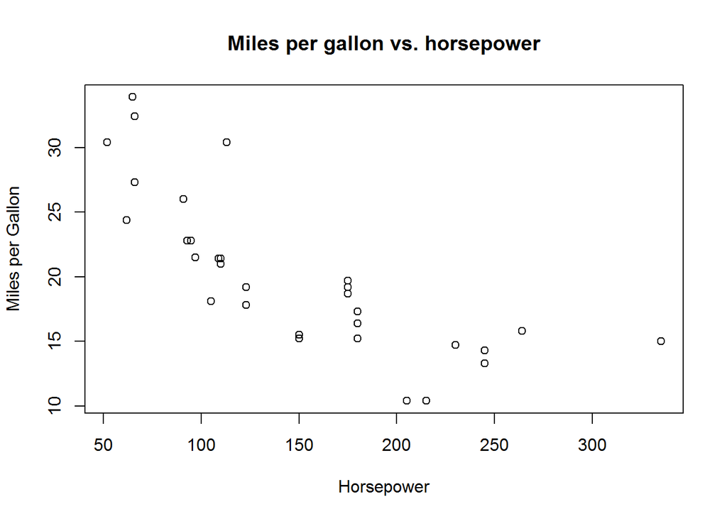

```r
plot(x = mtcars$hp, y = mtcars$mpg,main="Miles per gallon vs. horsepower",xlab="Horsepower",ylab = "Miles per Gallon")
```

Here are similar plots using ggplot which demonstrates three side-by-side graphs with the same x and y axes:

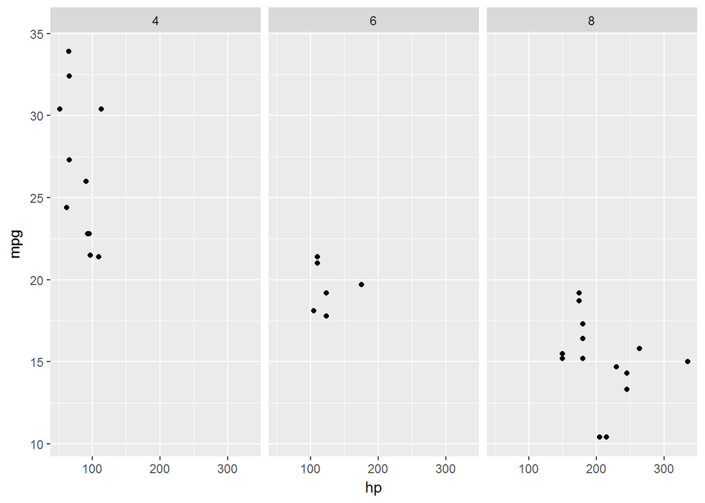

```r
ggplot (mtcars,aes(x=hp,y=mpg)) + geom_point() + facet_wrap (~cyl,nrow=1)
```

Try using ggplot and place the graphs 3 accross and two down, with Sepal in the upper set of graphs and petal in the lower.

Put the code for your plot here.

#### Add linear regression line

Now with one of the ggplot renderings, add a linear regression line to the plot. For example:

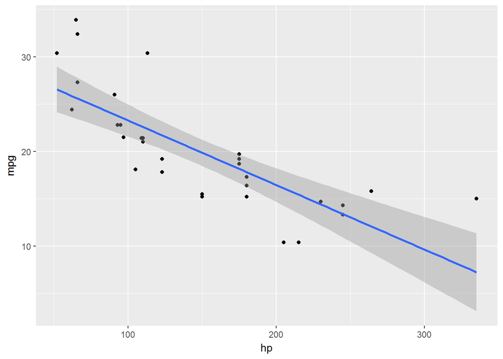

```r
#  (by default includes 95% confidence region)

ggplot (mtcars,aes(x=hp,y=mpg)) + geom_point() + geom_smooth(method=lm)
```

Your code goes here:

setosa = iris[iris$Species==“setosa”,] versicolor = iris[iris$Species==“versicolor”,] virginica = iris[iris$Species==“virginica”,]

#### Use the gather function from the tidyr library to compute mean and standard deviations without having to explicitly name each of the length and width columns. Try writing this as one R statement.

Your code goes here:

Pointer to dplyr and tidyr

https://rpubs.com/bradleyboehmke/data_wrangling

#### Explore the use of 3 dimensional plotting with the plotly library. Use the plot_ly function. Plot the dimensions on the x,y, and z coordinates and the species with colors.

Here is an example:

```r
library(plotly)
mtcars$am[which(mtcars$am == 0)] = 'Automatic'
mtcars$am[which(mtcars$am == 1)] = 'Manual'
mtcars$am = as.factor(mtcars$am)

p = plot_ly(mtcars, x = ~wt, y = ~hp, z = ~qsec, color = ~am,
            colors = c('#BF382A', '#0C4B8E')) %>%
            add_markers() %>%
            layout(scene = list(xaxis = list(title = 'Weight'),
                     yaxis = list(title = 'Gross horsepower'),
                     zaxis = list(title = '1/4 mile time')))
p
```

[interactive chart not shown]

#### Based on your graphs that you created, explore potential machine learning questions.

If you were considering a machine learning algorithm to predict iris species based on the measured attributes, which species do you think the the algorithm will do best?

Why?

With which two species is there a possibility of errors in prediction?

Why?

### Appendix

Here is an example with the mtcars sample dataset.

library(plotly)

Nice web app for visualization https://yuyangliu.shinyapps.io/iris_result/

https://www.kaggle.com/c34klh123/iris-data-with-ggplot-shiny/notebook

http://tutorials.iq.harvard.edu/R/Rgraphics/Rgraphics.html

Nice 3d plotting libraries

Plotly - https://plot.ly/r/

plot3D - http://www.sthda.com/english/wiki/impressive-package-for-3d-and-4d-graph-r-software-and-data-visualization

Discussion of pipes https://www.r-bloggers.com/simpler-r-coding-with-pipes-the-present-and-future-of-the-magrittr-package/

Nice collection of ggplot graphs: http://r-statistics.co/Top50-Ggplot2-Visualizations-MasterList-R-Code.html

test<-function(df) df[chull(df$Sepal.Length,df$Sepal.Width),]